# Chapter6

BB

9 december 2018

# Chapter 6

## RATS

First we read the long form of the RATS dataset created in the data wrangling. We factor the categorical variables again, because R does not recognize them as such.

We first make a graphical display of the weight of all individual rats over time, separated by the different diets (Groups) the rats were exposed to. The rats in group 1 have weight all below 300 grams over time. The rats with diet 2 and 3 vary approximately between 400 and 600 grams. All rats’ weight seems to have a tendency to increase over time.

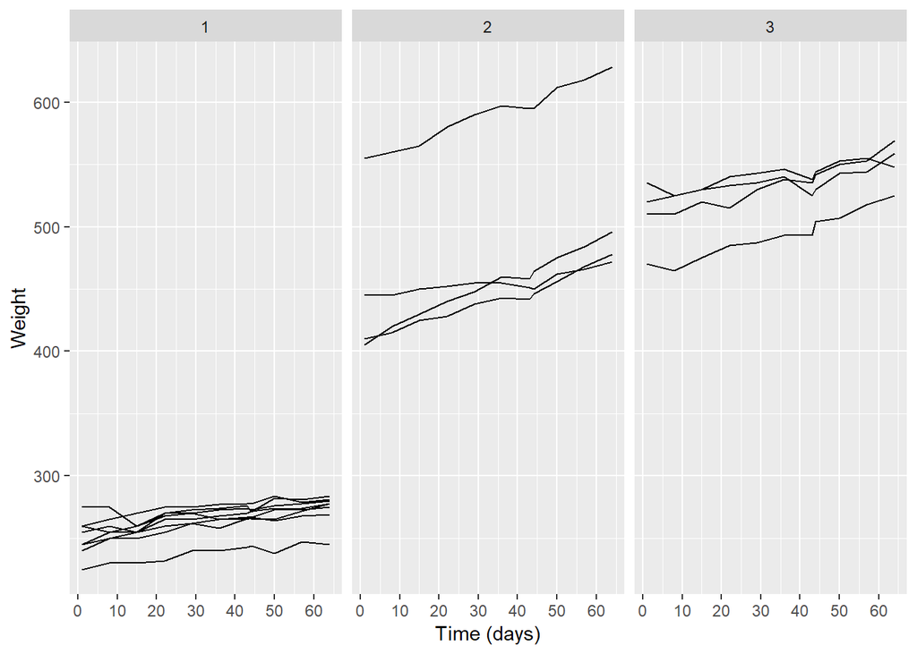

```r
# set working directory
setwd("C:/Users/Bram/Desktop/Open data science course/GitHub/IODS-project/data")

#read the long forms of the RATS dataset
RATSL <- read.table(file = "RATSL.txt", header = TRUE, sep = " ", dec = ".")

# Factor variables ID and Group
RATSL$ID <- factor(RATSL$ID)
RATSL$Group <- factor(RATSL$Group)

#Access the package ggplot2
library(ggplot2)
library(tidyr)
library(dplyr)
# Draw the plot
ggplot(RATSL, aes(x = Time, y = Weight, group = ID)) +
  geom_line() + facet_grid(. ~ Group) + scale_x_continuous(name = "Time (days)", breaks = seq(0, 60, 10)) + theme(legend.position = "none")
```

The rats who have higher weight at the beginning seem to have higher weight at the ending. This phenomenon is known as tracking and can be visualized even more strongly through standardizing the data and making another plot.

```r
# Standardize the weight variable
RATSL <- RATSL %>%
  group_by(Time) %>%
  mutate(stdWeight = (Weight - mean(Weight))/sd(Weight) ) %>%
  ungroup()

# Glimpse the data
glimpse(RATSL)
```

```
## Observations: 176
## Variables: 6
## $ ID        <fct> 1, 2, 3, 4, 5, 6, 7, 8, 9, 10, 11, 12, 13, 14, 15, 1...
## $ Group     <fct> 1, 1, 1, 1, 1, 1, 1, 1, 2, 2, 2, 2, 3, 3, 3, 3, 1, 1...
## $ WD        <fct> WD1, WD1, WD1, WD1, WD1, WD1, WD1, WD1, WD1, WD1, WD...
## $ Weight    <int> 240, 225, 245, 260, 255, 260, 275, 245, 410, 405, 44...
## $ Time      <int> 1, 1, 1, 1, 1, 1, 1, 1, 1, 1, 1, 1, 1, 1, 1, 1, 8, 8...
## $ stdWeight <dbl> -1.0011429, -1.1203857, -0.9613953, -0.8421525, -0.8...
```

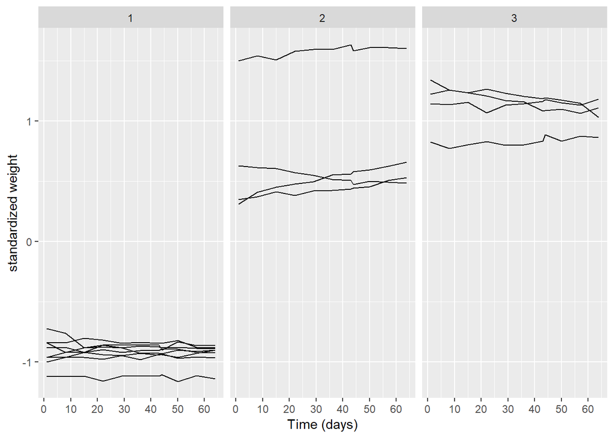

```r
# Plot again with the standardised rat weight
ggplot(RATSL, aes(x = Time, y = stdWeight, group = ID)) +
  geom_line() + facet_grid(. ~ Group, labeller = labeller(.rows = label_both, .cols = label_value)) + scale_x_continuous(name = "Time (days)", breaks = seq(0, 60, 10)) + theme(legend.position = "none") + scale_y_continuous(name = "standardized weight")
```

Because plots with individual data may be slightly chaotic (especially in large datasets), it is useful to make a summary plot and get a general overview of the weight progression over time in the rats with different diets. First we show the mean progression in a line diagram (lines from lowest to highest in order of group 1,2,3).

Then we generate a boxplot leaving out the baseline data (time after timepoint 1). the mean group weight is exposed with the orange diamond. There seem to be no outliers, as there are no data points outside the range of any of the boxes. Hence, we can keep on using the dataset as it is for the following t-test and anova.

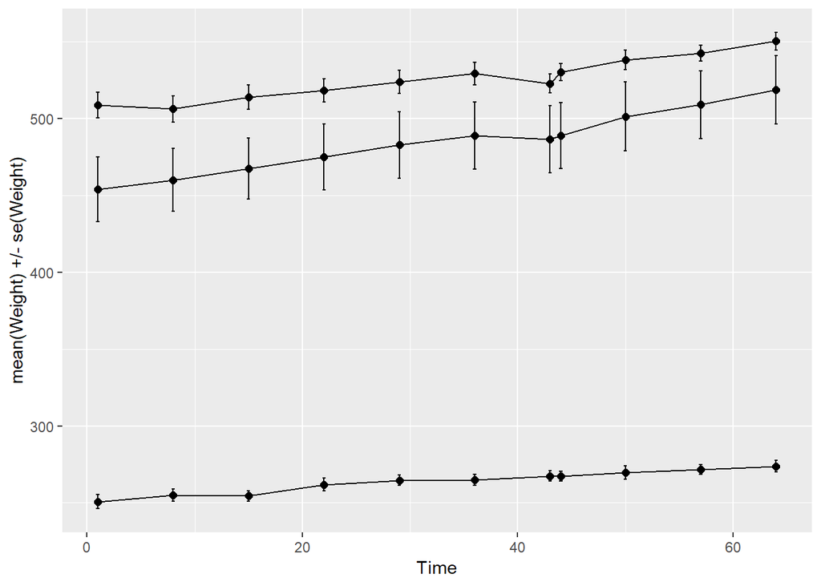

```r
# All number of days defined as n
n <- RATSL$Time %>% unique() %>% length()

# Summary data with mean and standard error of weight by Group (diet) and time in days
RATSS <- RATSL %>%
  group_by(Group, Time) %>%
  summarise( mean = mean(Weight), se = sd(Weight)/sqrt(n) ) %>%
  ungroup()

# Plot the mean profiles
ggplot(RATSS, aes(x = Time, y = mean, group = Group)) +
  geom_line() +
  geom_point(size=2) +
  geom_errorbar(aes(ymin = mean - se, ymax = mean + se), width=0.3) +
  theme(legend.position = c(0.8,0.8)) +
  scale_y_continuous(name = "mean(Weight) +/- se(Weight)")
```

```r
# Create a summary data by Group and Time with mean weight as the summary variable (ignoring baseline week 0).
RATSLS <- RATSL %>%
  filter(Time > 1) %>%
  group_by(Group, Time) %>%
  summarise(mean=mean(Weight)) %>%
  ungroup()

str(RATSLS$Time)
```

```
##  int [1:30] 8 15 22 29 36 43 44 50 57 64 ...
```

```r
# Glimpse the data
glimpse(RATSLS)
```

```
## Observations: 30
## Variables: 3
## $ Group <fct> 1, 1, 1, 1, 1, 1, 1, 1, 1, 1, 2, 2, 2, 2, 2, 2, 2, 2, 2,...
## $ Time  <int> 8, 15, 22, 29, 36, 43, 44, 50, 57, 64, 8, 15, 22, 29, 36...
## $ mean  <dbl> 255.000, 254.375, 261.875, 264.625, 265.000, 267.375, 26...
```

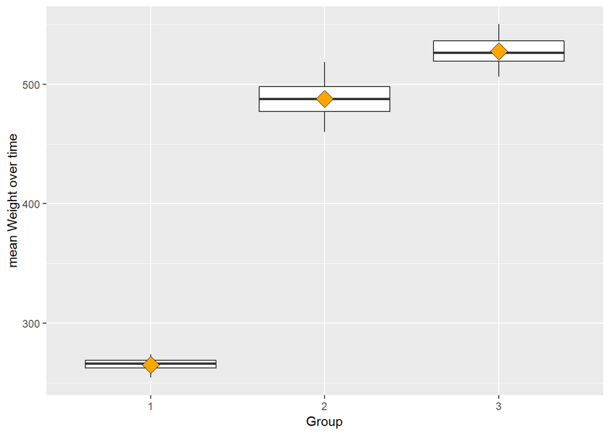

```r
# Draw a boxplot of the mean versus treatment
ggplot(RATSLS, aes(x = Group, y = mean, group = Group)) +
  geom_boxplot() +
  stat_summary(fun.y = "mean", geom = "point", shape=23, size=5, fill = "orange") +
  scale_y_continuous(name = "mean Weight over time")
```

I had a hard time finding out how to do the t-test in this data set. Also, I tried to mutate the following way, but it didnt work: RATS <- read.table(“https://raw.githubusercontent.com/KimmoVehkalahti/MABS/master/Examples/data/rats.txt”, sep =“”, header = T).

RATSLS2 <- RATSLS %>% mutate(baseline = RATS$WD1)

The ANOVA shows there is a significant difference between the groups. However, I suspect this may be a baseline difference and could’ve been corrected for if the analysis of covariance had been performed properly with the correct baseline variable.

```r
#How to perform the t-test in this data set?

# Add the baseline from the original data as a new variable to the summary data.
RATSLS2 <- RATSLS %>%
  mutate(baseline = RATSL$Time[1])

# Fit the linear model with the mean as the response
fit <- lm(mean ~ baseline + Group, data = RATSLS2)

# Compute the analysis of variance table for the fitted model
anova(fit)
```

```
## Analysis of Variance Table
##
## Response: mean
##           Df Sum Sq Mean Sq F value    Pr(>F)
## Group      2 400326  200163    1091 < 2.2e-16 ***
## Residuals 27   4953     183
## ---
## Signif. codes:  0 '***' 0.001 '**' 0.01 '*' 0.05 '.' 0.1 ' ' 1
```